# Raster : relief du Liban et de la Corse

- Show All Code
- Hide All Code
- View Source

Author

Dr. Elisabetta Pietrostefani

Published

November 5, 2026

## 0.1 Introduction

Jusqu’ici, nous avons travaillé avec des données **vectorielles** : des points, des lignes et des polygones, chacun avec une géométrie et une ligne dans un tableau. Les données **raster** fonctionnent autrement : c’est une grille régulière de cellules (ou pixels), chacune portant **une seule valeur**, sans tableau d’attributs.

Cette différence compte plus qu’il n’y paraît. Un raster ne connaît ni les « communes » ni les « ménages » : il sait seulement que la cellule (1450, 2013) vaut 847. Une grande partie du travail sur les rasters consiste donc à faire le pont entre *une grille de nombres* et *les données sociales et administratives* qui nous intéressent.

Nous travaillons sur deux territoires au relief contrasté, une côte méditerranéenne et des montagnes qui dépassent 2 700 m :

- **Partie 1 — Le Liban (guidé)** : on découvre chaque opération pas à pas ;
- **Partie 2 — La Corse (à vous)** : vous reproduisez la démarche, avec un corrigé à déplier ;
- **Partie 3 — Comparer** : on met les deux territoires côte à côte.

**TipCe que vous saurez faire à la fin**

| Opération | Fonction |
| --- | --- |
| Charger et explorer un raster | `rast()` |
| Reprojeter | `project()` |
| Recadrer et masquer | `crop()` + `mask()` |
| Changer la résolution | `aggregate()` |
| Calculer la pente | `terrain()` |
| Reclassifier | `classify()` |
| Extraire des valeurs en des points | `extract()` |
| Calculer des statistiques par zone | `exact_extract()` |

```r
library(terra)          # manipulation des rasters
library(tidyterra)      # geom_spatraster() et palettes pour ggplot2
library(sf)             # données vectorielles
library(ggplot2)        # visualisation
library(dplyr)          # manipulation de données
library(exactextractr)  # statistiques zonales

terraOptions(progress = 0)   # masquer les barres de progression de terra
```

**NoteInstaller les packages si nécessaire**

```r
install.packages(c("terra", "tidyterra", "exactextractr"))
```

`terra` remplace l’ancien package `raster` (déprécié depuis 2023). Si vous trouvez du code en ligne qui utilise `raster`, les fonctions se traduisent assez directement : `raster()` → `rast()`, `extent()` → `ext()`. `tidyterra` permet d’utiliser les rasters dans `ggplot2` avec `geom_spatraster()`.

# Partie 1 — Le Liban (guidé)

## 0.2 Charger et explorer le MNT

Un **MNT** (*Modèle Numérique de Terrain*) est un raster dont chaque cellule contient une altitude.

```r
dem_lb <- rast("data/Liban/LBN_elevation_w_bathymetry.tif")
dem_lb
```

```
class       : SpatRaster
size        : 708, 1150, 1  (nrow, ncol, nlyr)
resolution  : 0.0025, 0.0025  (x, y)
extent      : 33.74907, 36.62407, 33.06327, 34.83327  (xmin, xmax, ymin, ymax)
coord. ref. : lon/lat WGS 84 (EPSG:4326)
source      : LBN_elevation_w_bathymetry.tif
name        : LBN_elevation_w_bathymetry
```

Prenez le temps de lire cet affichage. Contrairement à un objet `sf`, il n’y a pas de lignes de tableau, mais :

- les **dimensions** : le nombre de lignes et de colonnes de cellules ;
- la **résolution** : la taille d’une cellule (ici 0,0025 degré, soit environ 250 m) ;
- l’**emprise** (*extent*) : le rectangle couvert ;
- le **système de coordonnées** (SCR) : ici WGS 84, en degrés.

C’est l’anatomie de tous les rasters que vous rencontrerez.

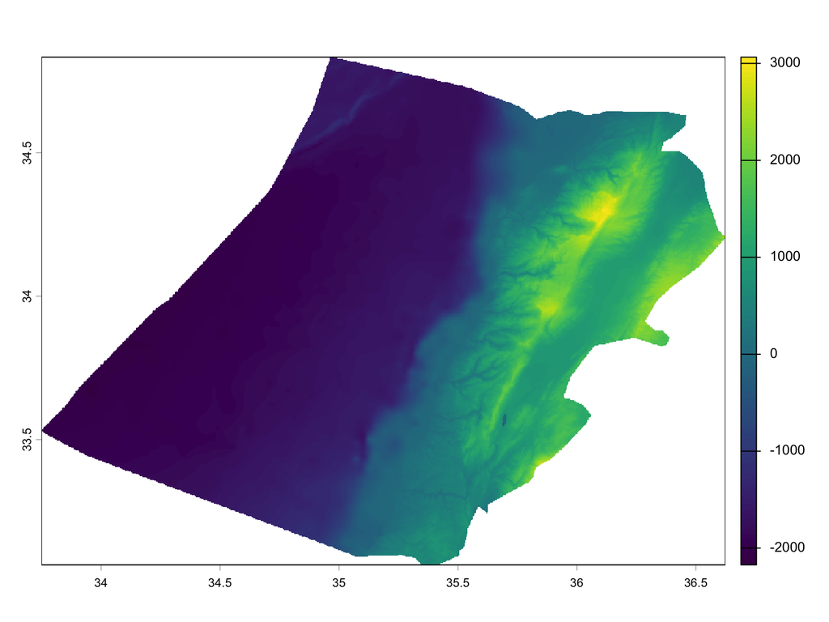

```r
plot(dem_lb)
```

Remarquez les valeurs négatives : ce fichier contient aussi la **bathymétrie** (la profondeur sous le niveau de la mer), c’est pourquoi la Méditerranée apparaît.

## 0.3 Le contour du pays et son SCR

```r
liban <- read_sf("data/Liban/LBN_adm1.shp")   # les gouvernorats (mohafazat)

st_crs(liban)$input
```

```
[1] "Deir ez Zor / Syria Lambert"
```

```r
crs(dem_lb, describe = TRUE)$name
```

```
[1] "WGS 84"
```

Les deux SCR sont différents : le raster est en degrés (WGS 84), le vecteur en mètres (Lambert syrien, EPSG:22770). Il faut les aligner avant toute opération.

## 0.4 Reprojeter le raster

On reprojette le raster dans le SCR du vecteur. Avantage : ce SCR est en **mètres**, ce qui nous servira pour calculer la pente.

```r
dem_lb <- project(dem_lb, crs(vect(liban)))
crs(dem_lb, describe = TRUE)$name
```

```
[1] "Deir ez Zor / Syria Lambert"
```

```r
res(dem_lb)   # résolution, désormais en mètres
```

```
[1] 244.501 244.501
```

**ImportantReprojeter un raster n’est pas anodin**

Reprojeter un **vecteur** déplace simplement des coordonnées. Reprojeter un **raster** oblige à construire une nouvelle grille et à *estimer* la valeur de chaque nouvelle cellule (par interpolation) : les données changent légèrement. Reprojetez une seule fois, le plus tôt possible.

`vect()` convertit un objet `sf` en objet vecteur de `terra` (`SpatVector`), le format attendu par les fonctions de `terra`.

## 0.5 Recadrer et masquer

Deux opérations pour se limiter à la zone d’étude :

- `crop()` **recadre** sur l’emprise rectangulaire du vecteur : le raster devient plus petit ;
- `mask()` **masque** tout ce qui est en dehors du contour exact : les cellules extérieures deviennent `NA`.

```r
dem_lb_crop <- crop(dem_lb, vect(liban))
dem_lb      <- mask(dem_lb_crop, vect(liban))
```

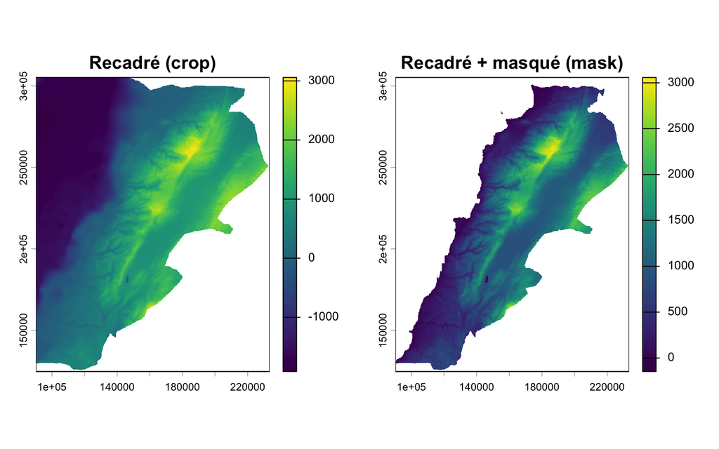

```r
par(mfrow = c(1, 2))
plot(dem_lb_crop, main = "Recadré (crop)")
plot(dem_lb,      main = "Recadré + masqué (mask)")
```

```r
par(mfrow = c(1, 1))
```

**TipPourquoi dans cet ordre ?**

`crop()` est une opération rapide (un simple rectangle) ; `mask()` doit tester chaque cellule contre le contour du polygone. **On recadre d’abord, on masque ensuite** : on réduit le problème avant l’étape coûteuse. Sur un grand raster, cela peut faire passer le calcul de plusieurs minutes à quelques secondes.

## 0.6 Cartographier le relief

`tidyterra` fournit `geom_spatraster()`, qui fait entrer un raster dans la grammaire de `ggplot2` que vous connaissez déjà.

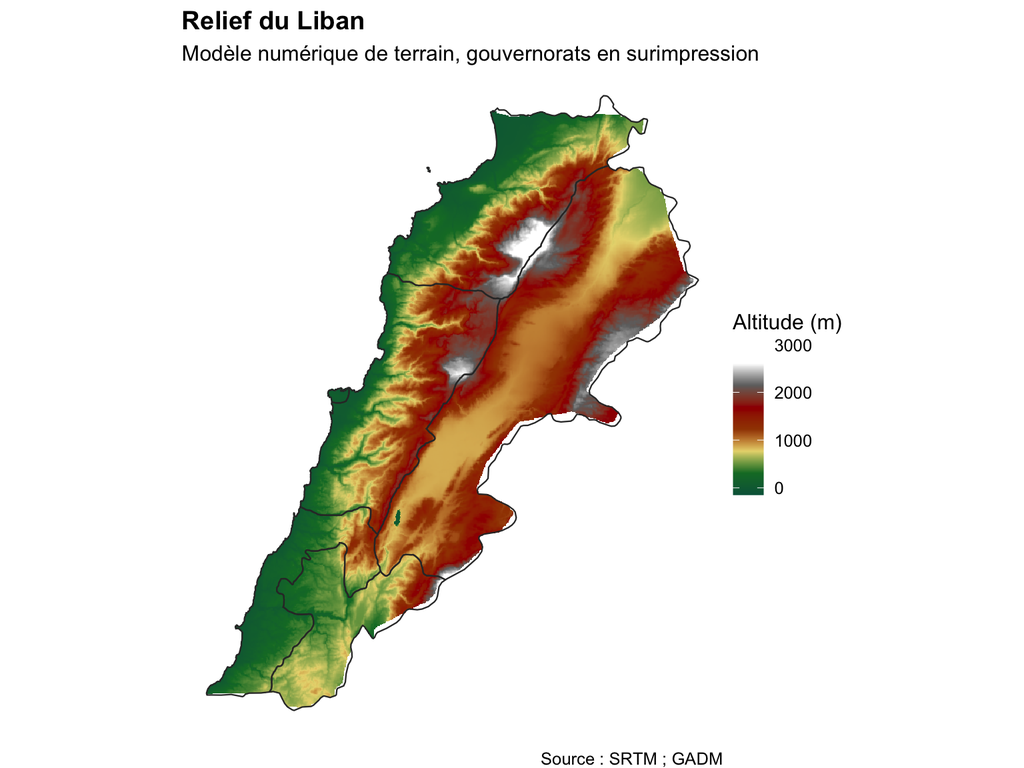

```r
ggplot() +
  geom_spatraster(data = dem_lb) +
  geom_sf(data = liban, fill = NA, colour = "grey20", linewidth = 0.4) +
  scale_fill_hypso_c(palette = "dem_poster", na.value = NA,
                     name = "Altitude (m)") +
  labs(title    = "Relief du Liban",
       subtitle = "Modèle numérique de terrain, gouvernorats en surimpression",
       caption  = "Source : SRTM ; GADM") +
  theme_void(base_size = 12) +
  theme(plot.title = element_text(face = "bold"))
```

`scale_fill_hypso_c()` utilise une palette **hypsométrique** : du vert (plaines) au brun puis au blanc (sommets), la convention des atlas physiques. C’est bien plus lisible pour le relief qu’une palette séquentielle générique.

## 0.7 Calculer la pente

La pente mesure l’inclinaison du terrain, en degrés. `terrain()` la calcule à partir des altitudes des cellules voisines.

```r
pente_lb <- terrain(dem_lb, v = "slope", unit = "degrees")

global(pente_lb, c("mean", "max"), na.rm = TRUE)
```

```
          mean     max
slope 7.774521 62.7342
```

**ImportantUn SCR en mètres est indispensable**

La pente compare une différence d’**altitude** (en mètres) à une distance **horizontale**. Si l’horizontale est en degrés, les deux unités sont incompatibles et la pente est fausse. C’est pourquoi on a reprojeté le MNT en mètres à l’étape précédente.

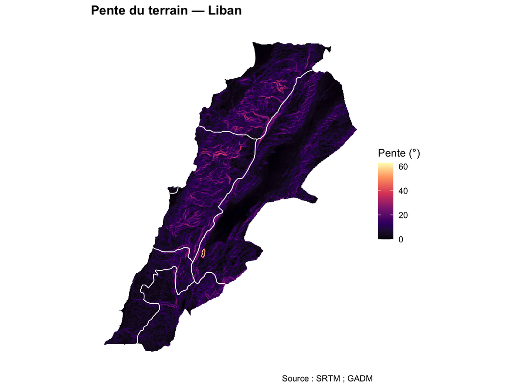

```r
ggplot() +
  geom_spatraster(data = pente_lb) +
  geom_sf(data = liban, fill = NA, colour = "white", linewidth = 0.4) +
  scale_fill_viridis_c(option = "magma", na.value = NA, name = "Pente (°)") +
  labs(title = "Pente du terrain — Liban",
       caption = "Source : SRTM ; GADM") +
  theme_void(base_size = 12) +
  theme(plot.title = element_text(face = "bold"))
```

Les deux chaînes de montagnes (Mont-Liban à l’ouest, Anti-Liban à l’est) ressortent nettement, séparées par la plaine de la Bekaa.

## 0.8 Reclassifier en zones d’altitude

La reclassification transforme un raster **continu** en **catégories**, selon des seuils. On utilise une matrice à trois colonnes : *de*, *à*, *nouvelle valeur*. On définit 4 zones, que l’on réutilisera telles quelles pour la Corse afin de pouvoir comparer.

```r
rcl <- matrix(c(
  -Inf,  200, 1,   # Littoral
   200,  800, 2,   # Basse montagne
   800, 1500, 3,   # Montagne
  1500,  Inf, 4    # Haute montagne
), ncol = 3, byrow = TRUE)

zones_lb <- classify(dem_lb, rcl)

# Noms des zones, utilisés pour la légende et les tableaux
noms_zones <- c("1" = "Littoral (< 200 m)",
                "2" = "Basse montagne (200–800 m)",
                "3" = "Montagne (800–1 500 m)",
                "4" = "Haute montagne (> 1 500 m)")
couleurs_zones <- c("1" = "#74add1", "2" = "#fee090",
                    "3" = "#fc8d59", "4" = "#d73027")

# Part de chaque zone (en % des cellules)
freq(zones_lb) |>
  mutate(zone = noms_zones[as.character(value)],
         part = round(count / sum(count) * 100, 1)) |>
  select(zone, part)
```

```
                        zone part
1         Littoral (< 200 m) 10.1
2 Basse montagne (200–800 m) 30.3
3     Montagne (800–1 500 m) 38.3
4 Haute montagne (> 1 500 m) 21.3
```

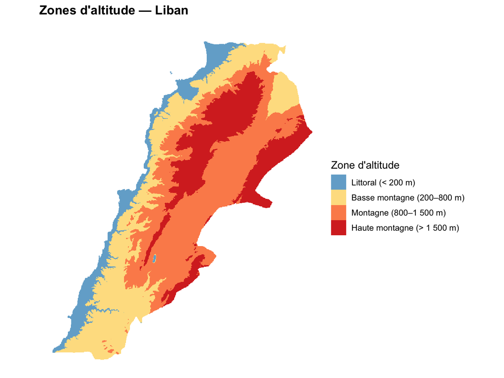

```r
ggplot() +
  geom_spatraster(data = as.factor(zones_lb)) +
  scale_fill_manual(values = couleurs_zones, labels = noms_zones,
                    na.value = NA, na.translate = FALSE,
                    name = "Zone d'altitude") +
  labs(title = "Zones d'altitude — Liban") +
  theme_void(base_size = 12) +
  theme(plot.title = element_text(face = "bold"))
```

## 0.9 Du raster au vecteur (1) : extraire des valeurs en des points

Voici le pont entre les deux modèles de données. On dispose d’un raster d’altitude et d’un ensemble de **points** : 2 000 ménages enquêtés (localisations fictives). On veut que chaque ménage connaisse son altitude.

```r
menages <- read_sf("data/Liban/random_survey_LBN.shp")
st_crs(menages)$input                         # WGS 84 : pas le même SCR que le raster !
```

```
[1] "WGS 84"
```

```r
menages <- st_transform(menages, crs(dem_lb)) # on aligne les SCR

# extract() lit la valeur du raster à chaque point
alt <- terra::extract(dem_lb, vect(menages))
menages$altitude <- alt[[2]]                  # 1re colonne = ID, 2e = valeur

summary(menages$altitude)
```

```
   Min. 1st Qu.  Median    Mean 3rd Qu.    Max.    NA's
 -98.22  491.20  963.62  991.22 1395.32 2936.39      35
```

**ImportantUne colonne remplie de `NA` ?**

C’est presque toujours un problème de **SCR** : les points et le raster ne sont pas dans le même système. Vérifiez avec `crs(dem_lb)` et `st_crs(menages)`, et reprojetez avant d’extraire. Ici, quelques `NA` sont normaux : ce sont des points situés juste en dehors du masque (en mer ou hors frontière).

À partir de là, l’altitude est un attribut comme un autre : on peut la résumer, la modéliser, ou la cartographier.

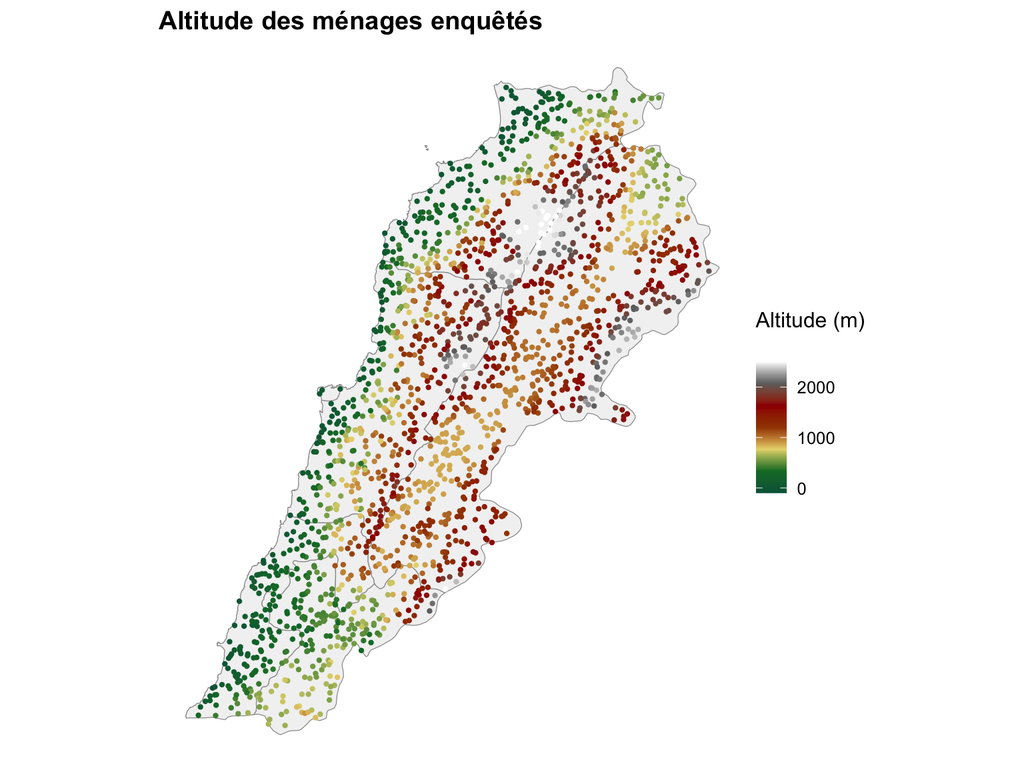

```r
ggplot() +
  geom_sf(data = liban, fill = "grey95", colour = "grey60") +
  geom_sf(data = filter(menages, !is.na(altitude)),
          aes(colour = altitude), size = 0.8) +
  scale_colour_hypso_c(palette = "dem_poster", name = "Altitude (m)") +
  labs(title = "Altitude des ménages enquêtés") +
  theme_void(base_size = 12) +
  theme(plot.title = element_text(face = "bold"))
```

## 0.10 Du raster au vecteur (2) : statistiques zonales

Les **statistiques zonales** résument toutes les cellules situées dans chaque polygone : on obtient **une valeur par zone administrative**, que l’on peut joindre et cartographier comme n’importe quelle variable. C’est le lien direct avec les cartes choroplèthes.

`exact_extract()` est rapide et tient compte des cellules qui ne sont que **partiellement** dans un polygone, en les pondérant par la fraction couverte.

```r
liban$alt_moy   <- exact_extract(dem_lb,   liban, "mean", progress = FALSE)
liban$pente_moy <- exact_extract(pente_lb, liban, "mean", progress = FALSE)

liban |>
  st_drop_geometry() |>
  select(NAME_1, alt_moy, pente_moy) |>
  arrange(desc(alt_moy))
```

```
# A tibble: 6 × 3
  NAME_1        alt_moy pente_moy
  <chr>           <dbl>     <dbl>
1 Beqaa          1306.       6.50
2 Mount Lebanon   998.      10.5
3 North Lebanon   851.       8.75
4 An Nabatiyah    642.       6.88
5 South Lebanon   382.       6.30
6 Beirut           44.4      3.10
```

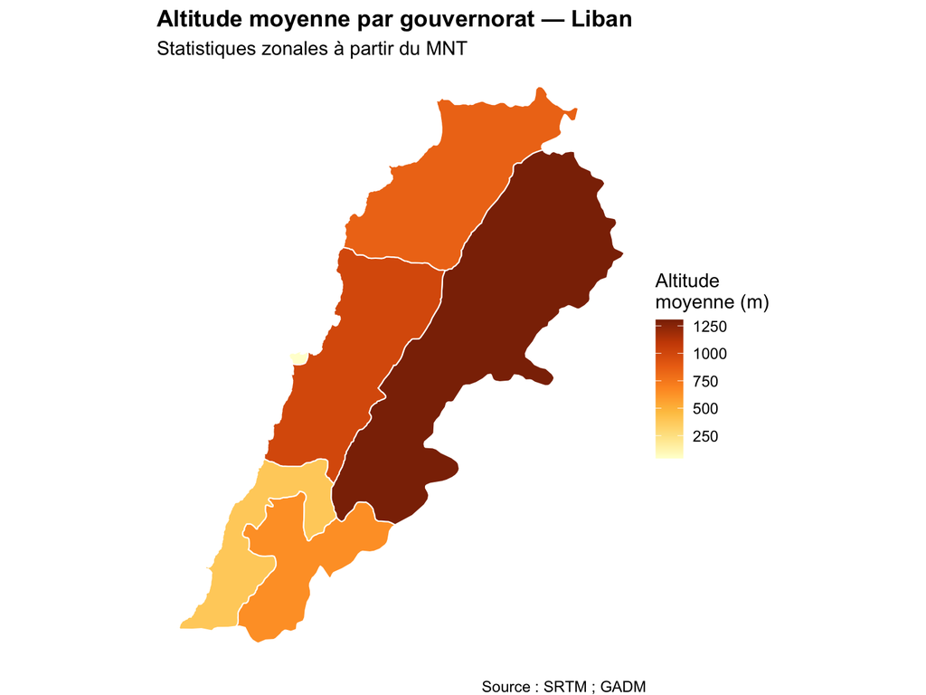

```r
ggplot(liban) +
  geom_sf(aes(fill = alt_moy), colour = "white", linewidth = 0.4) +
  scale_fill_distiller(palette = "YlOrBr", direction = 1,
                       name = "Altitude\nmoyenne (m)") +
  labs(title    = "Altitude moyenne par gouvernorat — Liban",
       subtitle = "Statistiques zonales à partir du MNT",
       caption  = "Source : SRTM ; GADM") +
  theme_void(base_size = 12) +
  theme(plot.title = element_text(face = "bold"))
```

La partie raster est terminée : le résultat est un objet `sf` ordinaire, avec une colonne numérique. C’est désormais une **carte choroplèthe** comme celles des séances précédentes.

# Partie 2 — La Corse (à vous)

La Corse présente un relief comparable au Liban : une côte méditerranéenne et un massif montagneux qui culmine au Monte Cinto (2 706 m). Reproduisez la démarche de la partie 1. Le corrigé de chaque étape est à déplier, **essayez d’abord par vous-mêmes**.

**Fichiers disponibles :**

| Fichier | Description |
| --- | --- |
| `data/France/Corse/Corse_tout_lambert.tif` | MNT de la Corse, en Lambert 93 (mètres) |
| `data/France/gadm41_FRA_shp/gadm41_FRA_5.shp` | Communes de France (GADM, niveau 5) |

## 0.11 Exercice 1 — Charger et explorer le MNT

Chargez le MNT de la Corse. Quel est son SCR ? Sa résolution ? Combien de cellules contient-il ? Comparez avec le Liban.

**TipCorrigé**

```r
dem_co <- rast("data/France/Corse/Corse_tout_lambert.tif")
dem_co
```

```
class       : SpatRaster
size        : 8602, 6691, 1  (nrow, ncol, nlyr)
resolution  : 27.27336, 27.27336  (x, y)
extent      : 1107784, 1290270, 6001901, 6236506  (xmin, xmax, ymin, ymax)
coord. ref. : RGF93 v1 / Lambert-93 (EPSG:2154)
source      : Corse_tout_lambert.tif
name        : Corse_tout_lambert
```

```r
ncell(dem_co)    # nombre de cellules
```

```
[1] 57555982
```

Le MNT est déjà en **Lambert 93** (EPSG:2154), en mètres : pas besoin de le reprojeter. Mais sa résolution est d’environ **27 m**, contre environ 250 m pour le Liban, et il compte plus de 57 millions de cellules, ce qui rendra certains calculs lents.

## 0.12 Exercice 2 — Harmoniser la résolution

Pour comparer les deux territoires, il faut travailler **à la même résolution** : une pente calculée sur des cellules de 27 m n’est pas comparable à une pente calculée sur des cellules de 250 m (plus les cellules sont fines, plus on capte de pentes fortes). Utilisez `aggregate()` pour ramener le MNT corse à une résolution proche de celle du Liban.

**TipCorrigé**

```r
# fact = 9 : on regroupe 9 × 9 cellules de 27 m en une cellule d'environ 245 m,
# dont la valeur est la moyenne des 81 cellules d'origine
dem_co <- aggregate(dem_co, fact = 9, fun = "mean")

res(dem_co)
```

```
[1] 245.4602 245.4602
```

```r
ncell(dem_co)
```

```
[1] 711264
```

Le raster est maintenant environ 80 fois plus léger, et directement comparable au Liban.

**NoteEt si le MNT était découpé en tuiles ?**

Les MNT à haute résolution sont souvent distribués en **tuiles** (`DEM_corse_1.tif` à `DEM_corse_4.tif` dans le dossier). On les assemble avec `mosaic(t1, t2, t3, t4, fun = "mean")` : la fonction `"mean"` s’applique aux cellules qui se chevauchent sur les bords.

## 0.13 Exercice 3 — Recadrer et masquer

Chargez les communes de France, gardez celles de la Corse (`NAME_1 == "Corse"`), mettez-les dans le SCR du MNT, puis recadrez et masquez le MNT.

**TipCorrigé**

```r
communes_co <- read_sf("data/France/gadm41_FRA_shp/gadm41_FRA_5.shp") |>
  filter(NAME_1 == "Corse") |>
  st_transform(crs(dem_co))    # GADM est en WGS 84 : on passe en Lambert 93

nrow(communes_co)              # 360 communes
```

```
[1] 360
```

```r
dem_co <- crop(dem_co, vect(communes_co)) |>
  mask(vect(communes_co))
```

Ici, on reprojette le **vecteur** plutôt que le raster : c’est sans perte, et le raster est déjà dans un SCR en mètres.

## 0.14 Exercice 4 — Cartographier le relief

Réalisez une carte hypsométrique du MNT corse, avec un titre et une source.

**TipCorrigé**

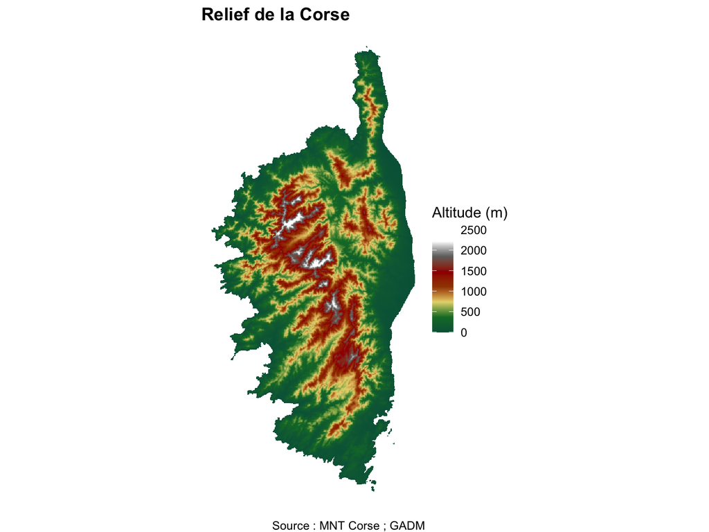

```r
ggplot() +
  geom_spatraster(data = dem_co) +
  scale_fill_hypso_c(palette = "dem_poster", na.value = NA,
                     name = "Altitude (m)") +
  labs(title   = "Relief de la Corse",
       caption = "Source : MNT Corse ; GADM") +
  theme_void(base_size = 12) +
  theme(plot.title = element_text(face = "bold"))
```

## 0.15 Exercice 5 — Calculer la pente

Calculez la pente en degrés, puis sa moyenne et son maximum. Pourquoi peut-on la calculer directement sur ce MNT ?

**TipCorrigé**

```r
pente_co <- terrain(dem_co, v = "slope", unit = "degrees")

global(pente_co, c("mean", "max"), na.rm = TRUE)
```

```
          mean      max
slope 12.76316 65.97884
```

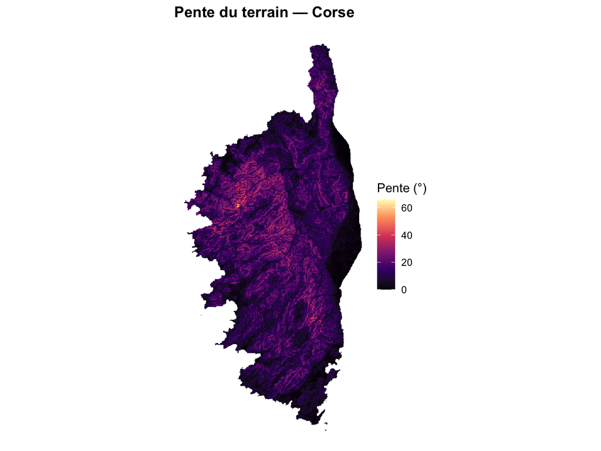

```r
ggplot() +
  geom_spatraster(data = pente_co) +
  scale_fill_viridis_c(option = "magma", na.value = NA, name = "Pente (°)") +
  labs(title = "Pente du terrain — Corse") +
  theme_void(base_size = 12) +
  theme(plot.title = element_text(face = "bold"))
```

On peut la calculer directement car le MNT est en **Lambert 93**, donc en mètres : altitude et distances horizontales ont la même unité.

## 0.16 Exercice 6 — Reclassifier en zones d’altitude

Reclassifiez le MNT avec **la même matrice** `rcl` que pour le Liban, puis calculez la part de chaque zone.

**TipCorrigé**

```r
zones_co <- classify(dem_co, rcl)   # même matrice que pour le Liban

freq(zones_co) |>
  mutate(zone = noms_zones[as.character(value)],
         part = round(count / sum(count) * 100, 1)) |>
  select(zone, part)
```

```
                        zone part
1         Littoral (< 200 m) 30.8
2 Basse montagne (200–800 m) 42.0
3     Montagne (800–1 500 m) 21.3
4 Haute montagne (> 1 500 m)  5.9
```

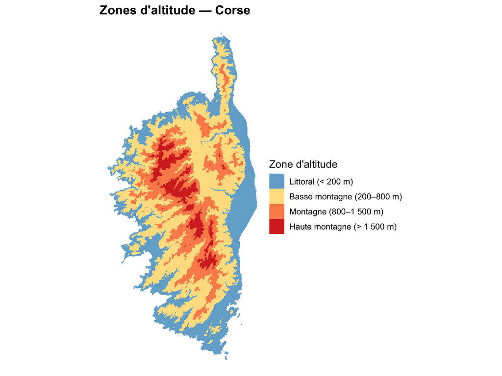

```r
ggplot() +
  geom_spatraster(data = as.factor(zones_co)) +
  scale_fill_manual(values = couleurs_zones, labels = noms_zones,
                    na.value = NA, na.translate = FALSE,
                    name = "Zone d'altitude") +
  labs(title = "Zones d'altitude — Corse") +
  theme_void(base_size = 12) +
  theme(plot.title = element_text(face = "bold"))
```

## 0.17 Exercice 7 — Statistiques zonales par commune

Calculez l’altitude moyenne de chaque commune corse avec `exact_extract()`, puis cartographiez-la. Quelles sont les communes les plus hautes ?

**TipCorrigé**

```r
communes_co$alt_moy <- exact_extract(dem_co, communes_co, "mean", progress = FALSE)

communes_co |>
  st_drop_geometry() |>
  select(NAME_5, alt_moy) |>
  arrange(desc(alt_moy)) |>
  head(5)
```

```
# A tibble: 5 × 2
  NAME_5       alt_moy
  <chr>          <dbl>
1 Lozzi          1561.
2 Casamaccioli   1524.
3 Albertacce     1437.
4 Asco           1380.
5 Ciamannacce    1316.
```

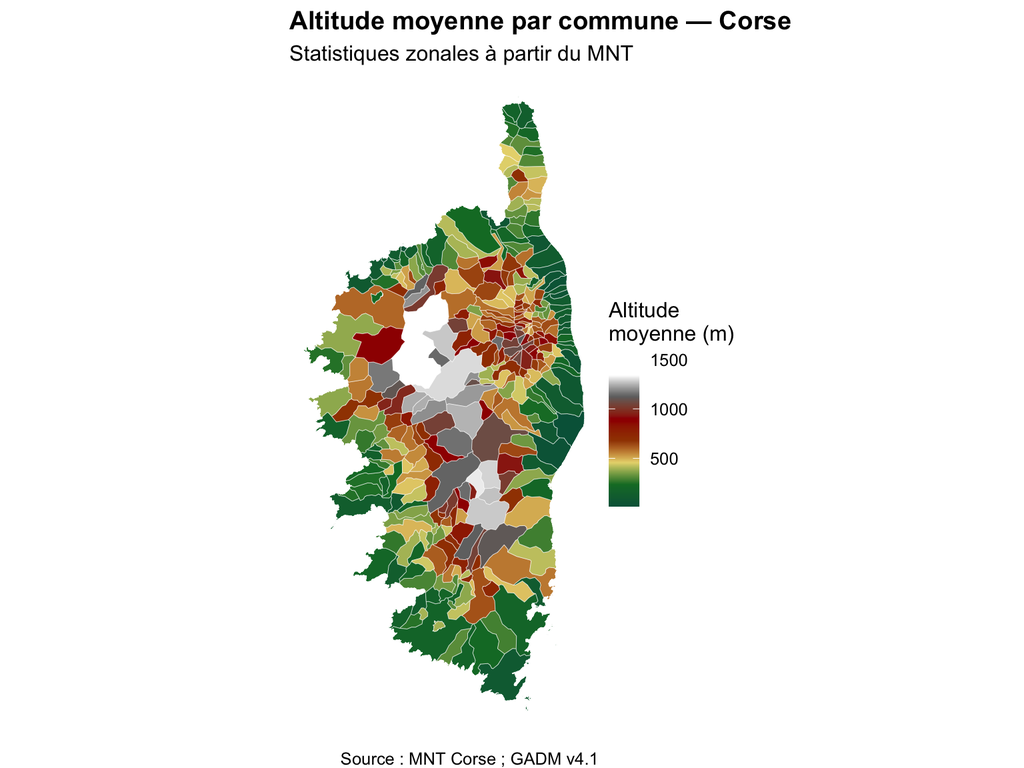

```r
ggplot(communes_co) +
  geom_sf(aes(fill = alt_moy), colour = "white", linewidth = 0.1) +
  scale_fill_hypso_c(palette = "dem_poster", name = "Altitude\nmoyenne (m)") +
  labs(title    = "Altitude moyenne par commune — Corse",
       subtitle = "Statistiques zonales à partir du MNT",
       caption  = "Source : MNT Corse ; GADM v4.1") +
  theme_void(base_size = 12) +
  theme(plot.title = element_text(face = "bold"))
```

Avec 360 communes, la carte est beaucoup plus détaillée que celle des gouvernorats libanais : le choix des **unités spatiales** change ce que la carte montre.

# Partie 3 — Comparer le Liban et la Corse

## 0.18 Un tableau de synthèse

Les deux MNT sont maintenant à une résolution comparable (environ 250 m), dans des SCR en mètres, et reclassifiés avec les mêmes seuils : on peut les comparer.

```r
synthese <- data.frame(
  territoire = c("Liban", "Corse"),
  alt_moy    = c(global(dem_lb,   "mean", na.rm = TRUE)[[1]],
                 global(dem_co,   "mean", na.rm = TRUE)[[1]]),
  alt_max    = c(global(dem_lb,   "max",  na.rm = TRUE)[[1]],
                 global(dem_co,   "max",  na.rm = TRUE)[[1]]),
  pente_moy  = c(global(pente_lb, "mean", na.rm = TRUE)[[1]],
                 global(pente_co, "mean", na.rm = TRUE)[[1]]),
  # surface = nombre de cellules non vides × surface d'une cellule (en km²)
  surface_km2 = c(global(!is.na(dem_lb), "sum")[[1]] * prod(res(dem_lb)) / 1e6,
                  global(!is.na(dem_co), "sum")[[1]] * prod(res(dem_co)) / 1e6)
)

knitr::kable(synthese, digits = c(0, 0, 0, 1, 0),
             col.names = c("Territoire", "Altitude moy. (m)", "Altitude max. (m)",
                           "Pente moy. (°)", "Surface (km²)"),
             caption = "Comparaison topographique Liban / Corse")
```

Comparaison topographique Liban / Corse

| Territoire | Altitude moy. (m) | Altitude max. (m) | Pente moy. (°) | Surface (km²) |
| --- | --- | --- | --- | --- |
| Liban | 991 | 3058 | 7.8 | 10202 |
| Corse | 555 | 2583 | 12.8 | 8915 |

## 0.19 Comparer les zones d’altitude

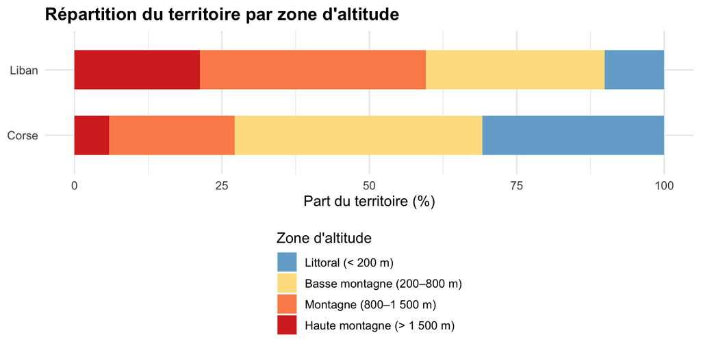

```r
parts <- bind_rows(
  freq(zones_lb) |> mutate(territoire = "Liban"),
  freq(zones_co) |> mutate(territoire = "Corse")
) |>
  group_by(territoire) |>
  mutate(part = count / sum(count) * 100,
         zone = factor(noms_zones[as.character(value)], levels = noms_zones)) |>
  ungroup()

ggplot(parts, aes(x = territoire, y = part, fill = zone)) +
  geom_col(width = 0.6) +
  scale_fill_manual(values = setNames(couleurs_zones, noms_zones),
                    name = "Zone d'altitude") +
  labs(x = NULL, y = "Part du territoire (%)",
       title = "Répartition du territoire par zone d'altitude") +
  coord_flip() +
  theme_minimal(base_size = 12) +
  theme(plot.title = element_text(face = "bold"),
        legend.position = "bottom", legend.direction = "vertical")
```

**NoteÀ discuter**

- Lequel des deux territoires est le plus **montagneux** ? Le plus **escarpé** ? Est-ce la même chose ?
- La surface calculée à partir des cellules est-elle exactement celle des sources officielles (Liban : 10 452 km² ; Corse : 8 680 km²) ? Pourquoi pas ?
- L’altitude maximale de la Corse dans le tableau est inférieure à celle du Monte Cinto (2 706 m). Pourquoi ? (Indice : que fait `aggregate(fun = "mean")` aux sommets ?)
- Que se passerait-il si l’on comparait la pente du Liban (cellules de 250 m) à celle de la Corse **sans** agréger le MNT corse (cellules de 27 m) ?

## 0.20 Récapitulatif

**NoteLes opérations raster essentielles**

```r
# 1. Charger et explorer
dem <- rast("fichier.tif")

# 2. Reprojeter (une seule fois, le plus tôt possible)
dem <- project(dem, crs(vect(vecteur)))

# 3. Recadrer puis masquer
dem <- crop(dem, vect(vecteur)) |> mask(vect(vecteur))

# 4. Harmoniser la résolution
dem <- aggregate(dem, fact = 9, fun = "mean")

# 5. Pente (SCR en mètres obligatoire)
pente <- terrain(dem, v = "slope", unit = "degrees")

# 6. Reclassifier
zones <- classify(dem, matrix(c(-Inf, 200, 1, 200, Inf, 2), ncol = 3, byrow = TRUE))

# 7. Du raster au vecteur
points$alt <- terra::extract(dem, vect(points))[[2]]           # en des points
polygones$alt_moy <- exact_extract(dem, polygones, "mean")     # par zone
```

## 0.21 Liens utiles

- [Documentation de `terra`](https://rspatial.github.io/terra/)
- [`tidyterra`](https://dieghernan.github.io/tidyterra/) — les rasters dans `ggplot2`
- [Spatial Data Science with R and `terra`](https://rspatial.org/) — livre en ligne gratuit
- [Geocomputation with R — opérations sur les rasters](https://r.geocompx.org/spatial-operations.html#spatial-ras)

*Dr. Elisabetta Pietrostefani — Directrice Adjointe, Geographic Data Science Lab — Université de Liverpool | Co-Directrice, [Imago : Data Service for Imagery](https://imago.ac.uk/) | Chercheuse Associée, London School of Economics*